# Simulated Probabilistic Distributions

#### 2.1.0.1 Determine which variables are most available

```r
#determine which lvl2_f are most abundant for crustacea data
crust <- aoc_z %>%
  dplyr::select(c(life.stage, bio.org, effect.metric, environment, exposure.route, lvl2_f, exposure.duration.d, treatments, lvl1_f, organism.group, dose.particles.mL.master, dose.mg.L.master, effect_f, effect_10, size.length.um.used.for.conversions, density.mg.um.3, csf)) %>%
 #filter(treatments == 4) %>%
  filter(organism.group == "Crustacea") %>%
  filter(exposure.duration.d == 14) %>%
  filter(lvl1_f == "Fitness") %>%
  #filter(life.stage == "Early") %>%
  filter(bio.org == "organism") %>%
 # filter(effect.metric == "NOEC") %>%
  #filter(environment == "Marine") %>%
  filter(exposure.route == "water") %>%
 filter(lvl2_f == "Mortality")

skim(crust)
```

Data summary

| Name | crust |
| --- | --- |
| Number of rows | 28 |
| Number of columns | 17 |
| _______________________ |  |
| Column type frequency: |  |
| factor | 9 |
| numeric | 8 |
| ________________________ |  |
| Group variables | None |

**Variable type: factor**

| skim_variable | n_missing | complete_rate | ordered | n_unique | top_counts |
| --- | --- | --- | --- | --- | --- |
| life.stage | 0 | 1.00 | FALSE | 1 | Ear: 28, Adu: 0, Juv: 0, Not: 0 |
| bio.org | 0 | 1.00 | FALSE | 1 | org: 28, cel: 0, pop: 0, sub: 0 |
| effect.metric | 18 | 0.36 | FALSE | 3 | HON: 4, LOE: 3, NOE: 3, EC1: 0 |
| environment | 0 | 1.00 | FALSE | 1 | Mar: 28, Fre: 0, Ter: 0 |
| exposure.route | 0 | 1.00 | FALSE | 1 | wat: 28, cop: 0, foo: 0, mat: 0 |
| lvl2_f | 0 | 1.00 | FALSE | 1 | Mor: 28, Abu: 0, Act: 0, Agr: 0 |
| lvl1_f | 0 | 1.00 | FALSE | 1 | Fit: 28, Ali: 0, Beh: 0, Cir: 0 |
| organism.group | 0 | 1.00 | FALSE | 1 | Cru: 28, Alg: 0, Ann: 0, Bac: 0 |
| effect_f | 0 | 1.00 | FALSE | 2 | N: 21, Y: 7 |

**Variable type: numeric**

| skim_variable | n_missing | complete_rate | mean | sd | p0 | p25 | p50 | p75 | p100 | hist |
| --- | --- | --- | --- | --- | --- | --- | --- | --- | --- | --- |
| exposure.duration.d | 0 | 1 | 1.400000e+01 | 0.00000e+00 | 14.00 | 14.00 | 14.00 | 1.400000e+01 | 1.40e+01 | ▁▁▇▁▁ |
| treatments | 0 | 1 | 4.000000e+00 | 0.00000e+00 | 4.00 | 4.00 | 4.00 | 4.000000e+00 | 4.00e+00 | ▁▁▇▁▁ |
| dose.particles.mL.master | 0 | 1 | 3.965639e+10 | 1.00899e+11 | 1.00 | 10329.37 | 9817033.88 | 1.784915e+09 | 3.57e+11 | ▇▁▁▁▁ |
| dose.mg.L.master | 0 | 1 | 8.350000e+00 | 1.00800e+01 | 0.00 | 0.12 | 1.25 | 1.250000e+01 | 2.50e+01 | ▇▁▃▁▃ |
| effect_10 | 0 | 1 | 2.500000e-01 | 4.40000e-01 | 0.00 | 0.00 | 0.00 | 2.500000e-01 | 1.00e+00 | ▇▁▁▁▂ |
| size.length.um.used.for.conversions | 0 | 1 | 3.370000e+00 | 3.91000e+00 | 0.05 | 0.05 | 0.50 | 6.000000e+00 | 1.05e+01 | ▇▁▃▁▂ |
| density.mg.um.3 | 0 | 1 | 0.000000e+00 | 0.00000e+00 | 0.00 | 0.00 | 0.00 | 0.000000e+00 | 0.00e+00 | ▁▁▇▁▁ |
| csf | 28 | 0 | NaN | NA | NA | NA | NA | NA | NA |  |

```r
crust2 <- crust %>% drop_na(effect_f) %>%  mutate_if(~is.numeric(.) && (.) > 0, log10)

#skim(crust2)
summary(glm(data = crust2, effect_10 ~ dose.particles.mL.master + dose.mg.L.master + size.length.um.used.for.conversions, na.action = "na.exclude", family = "binomial"))
```

```
##
## Call:
## glm(formula = effect_10 ~ dose.particles.mL.master + dose.mg.L.master +
##     size.length.um.used.for.conversions, family = "binomial",
##     data = crust2, na.action = "na.exclude")
##
## Deviance Residuals:
##    Min      1Q  Median      3Q     Max
## -1.177   0.000   0.000   0.000   1.177
##
## Coefficients:
##                                     Estimate Std. Error z value Pr(>|z|)
## (Intercept)                           -20470   13115120  -0.002    0.999
## dose.particles.mL.master                3254    2089691   0.002    0.999
## dose.mg.L.master                       -3187    2063650  -0.002    0.999
## size.length.um.used.for.conversions     9652    6220812   0.002    0.999
##
## (Dispersion parameter for binomial family taken to be 1)
##
##     Null deviance: 31.4908  on 27  degrees of freedom
## Residual deviance:  2.7726  on 24  degrees of freedom
## AIC: 10.773
##
## Number of Fisher Scoring iterations: 24
```

## 2.2 Predict Toxicities

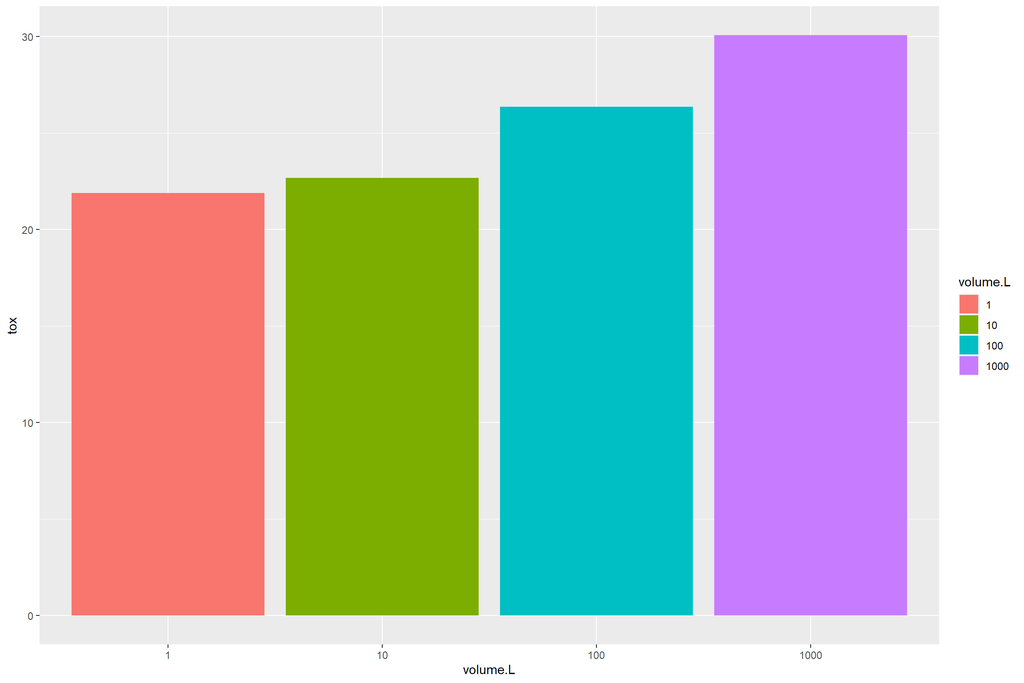

```r
#pull in model from DALEX
final_model <- readRDS("final_rf_model.rds")

#### prep data frames ####
df_1L_f <- df_1L %>%
  mutate_if(~is.numeric(.) && (.) > 0, log10) #model has everything log-transformed

df_10L_f <- df_10L %>%
  mutate_if(~is.numeric(.) && (.) > 0, log10) #model has everything log-transformed

df_100L_f <- df_100L %>%
  mutate_if(~is.numeric(.) && (.) > 0, log10) #model has everything log-transformed

df_1000L_f <- df_1000L %>%
  mutate_if(~is.numeric(.) && (.) > 0, log10) #model has everything log-transformed

#### Predict Toxicity ####
df_1L_p <- predict(final_model, newdata = df_1L_f, type = "prob") %>%  rename("ToxicityProbability" = `1`)
df_1L_p_f <- cbind(df_1L, df_1L_p)

df_10L_p <- predict(final_model, newdata = df_10L_f, type = "prob") %>%  rename("ToxicityProbability" = `1`)
df_10L_p_f <- cbind(df_10L, df_10L_p)

df_100L_p <- predict(final_model, newdata = df_100L_f, type = "prob") %>%  rename("ToxicityProbability" = `1`)
df_100L_p_f <- cbind(df_100L, df_100L_p)

df_1000L_p <- predict(final_model, newdata = df_1000L_f, type = "prob") %>%  rename("ToxicityProbability" = `1`)
df_1000L_p_f <- cbind(df_1000L, df_1000L_p)

df_pred <- rbind(df_1L_p_f, df_10L_p_f, df_100L_p_f, df_1000L_p_f)

prob_summ <- df_pred %>% mutate(volume.L = as.factor(vol.L)) %>%  group_by(volume.L) %>% summarize(tox = sum(ToxicityProbability))

prob_summ %>% ggplot(aes(x = volume.L, y = tox, fill = volume.L)) +geom_col()
```

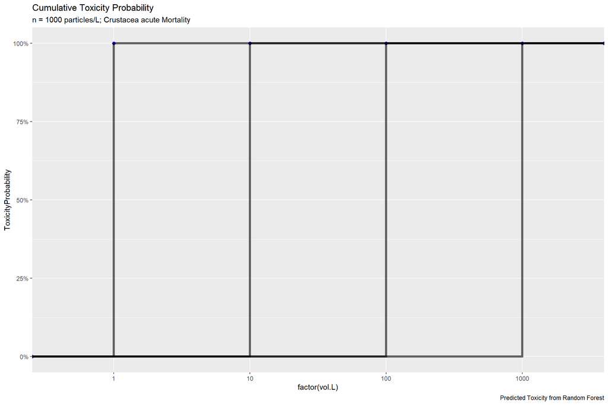

```r
df_pred %>% ggplot(aes(x = factor(vol.L), y = ToxicityProbability)) +
  stat_ecdf(geom = "point", size = 2, color = "blue")+
  stat_ecdf(geom = "step", linetype = 'solid', alpha = 0.6, size = 1.5) +
  #scale_x_log10() +
  scale_y_continuous(labels = scales::percent)+
  labs(title = "Cumulative Toxicity Probability",
       subtitle = "n = 1000 particles/L; Crustacea acute Mortality",
       caption = "Predicted Toxicity from Random Forest")
```

# 3 Volume Constant, Particles different

## 3.1 Generate Particles

### 3.1.1 5 particles in 1 L

### 3.1.2 10 particles in 1 L

### 3.1.3 20 particles in 1 L

### 3.1.4 40 particles in 1 L

### 3.1.5 80 particles in 1 L

### 3.1.6 160 particles in 1 L

### 3.1.7 320 particles in 1 L

### 3.1.8 480 particles in 1 L

### 3.1.9 640 particles in 1 L

### 3.1.10 1000 particles

### 3.1.11 1280 particles

Parameters: Shape, density, size, why do 3 polymers? Leave polymer out for now. For mechanistic point of view- polymer does not matter.

## 3.2 Predict Toxicities

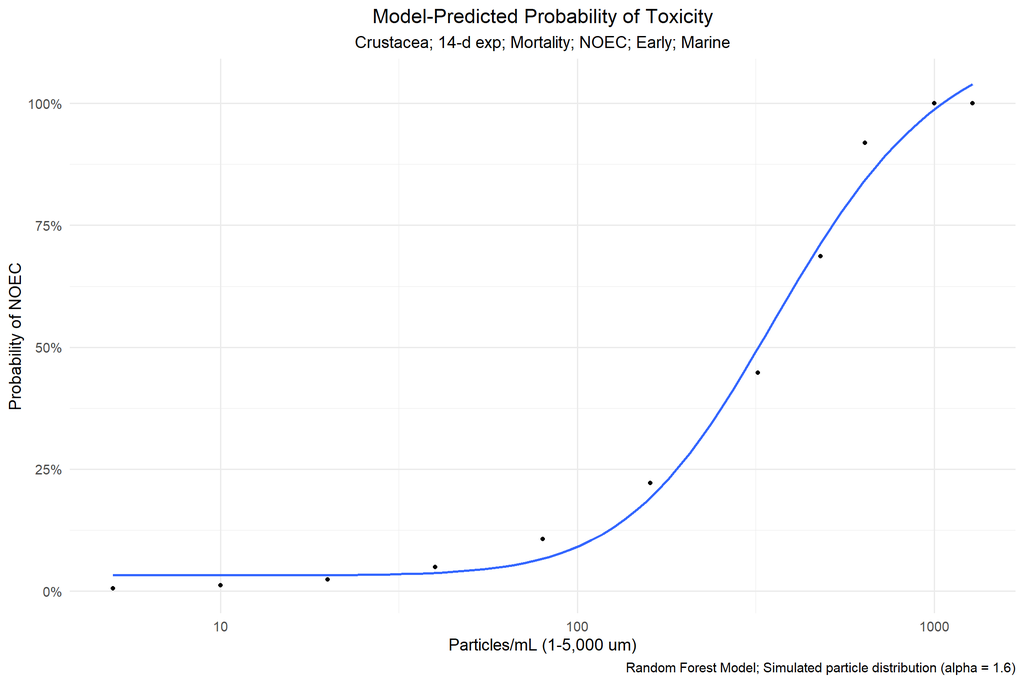

```r
#pull in model from DALEX
final_model <- readRDS("final_rf_model.rds")

#### prep data frames ####
df_5p_f <- Data_5p %>%
  mutate_if(~is.numeric(.) && (.) > 0, log10) #model has everything log-transformed

df_10p_f <- Data_10p %>%
  mutate_if(~is.numeric(.) && (.) > 0, log10) #model has everything log-transformed

df_20p_f <- Data_20p %>%
  mutate_if(~is.numeric(.) && (.) > 0, log10) #model has everything log-transformed

df_40p_f <- Data_40p %>%
  mutate_if(~is.numeric(.) && (.) > 0, log10) #model has everything log-transformed

df_80p_f <- Data_80p %>%
  mutate_if(~is.numeric(.) && (.) > 0, log10) #model has everything log-transformed

df_160p_f <- Data_160p %>%
  mutate_if(~is.numeric(.) && (.) > 0, log10) #model has everything log-transformed

df_320p_f <- Data_320p %>%
  mutate_if(~is.numeric(.) && (.) > 0, log10) #model has everything log-transformed

df_480p_f <- Data_480p %>%
  mutate_if(~is.numeric(.) && (.) > 0, log10) #model has everything log-transformed

df_640p_f <- Data_640p %>%
  mutate_if(~is.numeric(.) && (.) > 0, log10) #model has everything log-transformed

df_1000p_f <- Data_1000p %>%
  mutate_if(~is.numeric(.) && (.) > 0, log10) #model has everything log-transformed

df_1280p_f <- Data_1280p %>%
  mutate_if(~is.numeric(.) && (.) > 0, log10) #model has everything log-transformed

#### Predict Toxicity ####
df_5p_p <- predict(final_model, newdata = df_5p_f, type = "prob") %>%  rename("ToxicityProbability" = `1`)
df_5p_p_f <- cbind(df_5p_f, df_5p_p)

df_10p_p <- predict(final_model, newdata = df_10p_f, type = "prob") %>%  rename("ToxicityProbability" = `1`)
df_10p_p_f <- cbind(df_10p_f, df_10p_p)

df_20p_p <- predict(final_model, newdata = df_20p_f, type = "prob") %>%  rename("ToxicityProbability" = `1`)
df_20p_p_f <- cbind(df_20p_f, df_20p_p)

df_40p_p <- predict(final_model, newdata = df_40p_f, type = "prob") %>%  rename("ToxicityProbability" = `1`)
df_40p_p_f <- cbind(df_40p_f, df_40p_p)

df_10p_p <- predict(final_model, newdata = df_10p_f, type = "prob") %>%  rename("ToxicityProbability" = `1`)
df_10p_p_f <- cbind(df_10p_f, df_10p_p)

df_80p_p <- predict(final_model, newdata = df_80p_f, type = "prob") %>%  rename("ToxicityProbability" = `1`)
df_80p_p_f <- cbind(df_80p_f, df_80p_p)

df_160p_p <- predict(final_model, newdata = df_160p_f, type = "prob") %>%  rename("ToxicityProbability" = `1`)
df_160p_p_f <- cbind(df_160p_f, df_160p_p)

df_320p_p <- predict(final_model, newdata = df_320p_f, type = "prob") %>%  rename("ToxicityProbability" = `1`)
df_320p_p_f <- cbind(df_320p_f, df_320p_p)

df_480p_p <- predict(final_model, newdata = df_480p_f, type = "prob") %>%  rename("ToxicityProbability" = `1`)
df_480p_p_f <- cbind(df_480p_f, df_480p_p)

df_640p_p <- predict(final_model, newdata = df_640p_f, type = "prob") %>%  rename("ToxicityProbability" = `1`)
df_640p_p_f <- cbind(df_640p_f, df_640p_p)

df_1000p_p <- predict(final_model, newdata = df_1000p_f, type = "prob") %>%  rename("ToxicityProbability" = `1`)
df_1000p_p_f <- cbind(df_1000p_f, df_1000p_p)

df_1280p_p <- predict(final_model, newdata = df_1280p_f, type = "prob") %>%  rename("ToxicityProbability" = `1`)
df_1280p_p_f <- cbind(df_1280p_f, df_1280p_p)

df_pred <- rbind(df_5p_p_f, df_10p_p_f, df_20p_p_f, df_40p_p_f, df_80p_p_f, df_160p_p_f, df_320p_p_f, df_480p_p_f, df_640p_p_f, df_1000p_p_f, df_1280p_p_f)

prob_summ <- df_pred %>% group_by(particles.total) %>% summarize(tox = sum(ToxicityProbability))

####convert >1 prob to 1 ###
prob_summ <- prob_summ %>%  mutate(probability = case_when(tox < 1 ~ tox, tox >=1 ~ 1)) %>%
  mutate(particles = as.numeric(str_sub(particles.total, end = -2))) %>%
  mutate(log.particles = log(particles))

#plot dose response relationship
prob_summ %>%
  ggplot(aes(x = particles, y = probability)) +
  geom_point() +
  stat_smooth(method = drm, method.args = list(fct = LL.4()), se = FALSE) + #logit-4 paramater curve
  scale_x_log10(name = "Particles/mL (1-5,000 um)") +
  scale_y_continuous(labels = scales::percent_format(),
                     name = "Probability of NOEC") +
  labs(title = "Model-Predicted Probability of Toxicity",
       subtitle = "Crustacea; 14-d exp; Mortality; NOEC; Early; Marine",
       caption = "Random Forest Model; Simulated particle distribution (alpha = 1.6)") +
  theme_minimal(base_size = 14) +
  theme(plot.title = element_text(hjust = 0.5),
        plot.subtitle = element_text(hjust = 0.5))
```

```r
# df_pred %>%
#   group_by(particles.total) %>%
#   summarize(tox_n = count(ToxicityProbability)) %>%
#   mutate(cum_tox = cumsum(tox_n)) %>%
#   ggplot(aes(x = Size, y = cum_tox)) +
#   geom_step() +
#   facet_wrap(~particles.total)

  #scale_x_log10() +
  # scale_y_continuous(labels = scales::percent)+
  # labs(title = "Cumulative Toxicity Probability",
  #      subtitle = "n = 1000 particles/mL; Crustacea acute Mortality",
  #      caption = "Predicted Toxicity from Random Forest")
```

```r
dose_response <- drm(data = prob_summ, probability ~ log.particles, fct = LL.4())
summary(dose_response)
```

```
##
## Model fitted: Log-logistic (ED50 as parameter) (4 parms)
##
## Parameter estimates:
##
##                 Estimate Std. Error t-value   p-value
## b:(Intercept) -11.321831   2.511631 -4.5078  0.002772 **
## c:(Intercept)   0.032572   0.023618  1.3792  0.210299
## d:(Intercept)   1.165786   0.106286 10.9684 1.160e-05 ***
## e:(Intercept)   5.956763   0.119938 49.6655 3.512e-10 ***
## ---
## Signif. codes:  0 '***' 0.001 '**' 0.01 '*' 0.05 '.' 0.1 ' ' 1
##
## Residual standard error:
##
##  0.04549059 (7 degrees of freedom)
```

```r
summary(glm(ToxicityProbability ~ Size * Shape * polymer * um3, data = df_640p_p_f))
```

```
##
## Call:
## glm(formula = ToxicityProbability ~ Size * Shape * polymer *
##     um3, data = df_640p_p_f)
##
## Deviance Residuals:
##        Min          1Q      Median          3Q         Max
## -1.587e-03  -1.394e-04   6.039e-05   2.025e-04   2.715e-03
##
## Coefficients: (6 not defined because of singularities)
##                            Estimate Std. Error t value Pr(>|t|)
## (Intercept)               1.981e-03  8.371e-05  23.670  < 2e-16 ***
## Size                     -1.698e-03  2.053e-04  -8.268 8.24e-16 ***
## Shape                     1.985e-05  1.493e-04   0.133  0.89428
## polymerPP                -2.551e-04  1.326e-04  -1.924  0.05476 .
## polymerPS                -1.041e-04  1.617e-04  -0.644  0.51987
## um3                              NA         NA      NA       NA
## Size:Shape                5.693e-05  4.023e-04   0.142  0.88751
## Size:polymerPP            7.918e-04  3.231e-04   2.450  0.01454 *
## Size:polymerPS            1.846e-04  3.491e-04   0.529  0.59712
## Shape:polymerPP          -4.637e-04  2.376e-04  -1.952  0.05140 .
## Shape:polymerPS          -2.988e-04  2.850e-04  -1.048  0.29488
## Size:um3                  2.124e-04  3.185e-05   6.671 5.62e-11 ***
## Shape:um3                        NA         NA      NA       NA
## polymerPP:um3                    NA         NA      NA       NA
## polymerPS:um3                    NA         NA      NA       NA
## Size:Shape:polymerPP      1.559e-03  5.706e-04   2.732  0.00646 **
## Size:Shape:polymerPS      7.432e-04  6.414e-04   1.159  0.24703
## Size:Shape:um3           -3.285e-05  6.764e-05  -0.486  0.62740
## Size:polymerPP:um3       -1.269e-04  4.591e-05  -2.765  0.00586 **
## Size:polymerPS:um3        1.898e-05  4.686e-05   0.405  0.68557
## Shape:polymerPP:um3              NA         NA      NA       NA
## Shape:polymerPS:um3              NA         NA      NA       NA
## Size:Shape:polymerPP:um3 -2.703e-04  8.258e-05  -3.273  0.00112 **
## Size:Shape:polymerPS:um3 -7.765e-05  8.834e-05  -0.879  0.37972
## ---
## Signif. codes:  0 '***' 0.001 '**' 0.01 '*' 0.05 '.' 0.1 ' ' 1
##
## (Dispersion parameter for gaussian family taken to be 1.799645e-07)
##
##     Null deviance: 0.00031564  on 639  degrees of freedom
## Residual deviance: 0.00011194  on 622  degrees of freedom
## AIC: -8103.5
##
## Number of Fisher Scoring iterations: 2
```

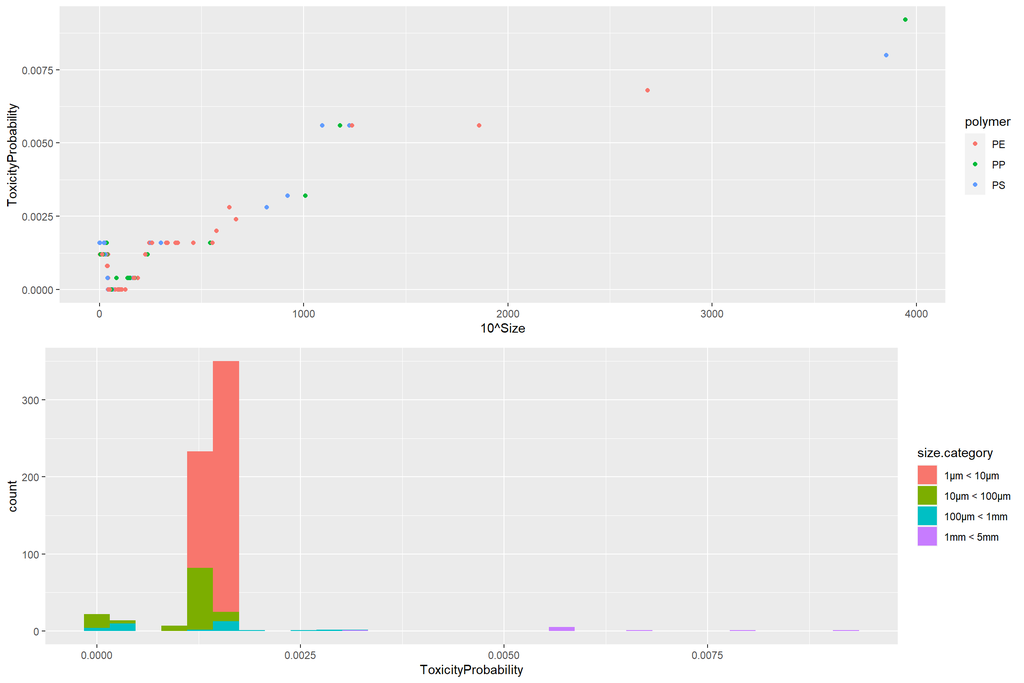

```r
p1 <- df_640p_p_f %>% ggplot(aes(x = 10^Size, y = ToxicityProbability, color = polymer)) + geom_point()

p2 <- df_640p_p_f %>% ggplot(aes(x = ToxicityProbability, fill = size.category)) + geom_histogram()
grid.arrange(p1,p2)
```

```r
#test toxicity prediction with a single row

dataFrame <- data.frame(Doubles=double(),
                 Ints=integer(),
                 Factors=factor(),
                 Logicals=logical(),
                 Characters=character(),
                 stringsAsFactors=FALSE)
newrow =data.frame(dose.particles.mL.master = 1)
# Compare with monodisperse prediction
monoDisperse_100 <- newrow %>%
 # mutate(dose.particles.mL.master = 120) %>%  #120 particles/mL is about EC50 for above
  mutate(mass.mg = 0.2263657 * 120) %>% #average mass x 120 particles
  mutate(um3 = 242182027) %>%
  mutate(treatments = 4) %>%
  mutate(organism.group = "Crustacea") %>%
  mutate(exposure.duration.d = 14) %>%
  mutate(lvl1_f = "Fitness") %>%
  mutate(life.stage= "Early") %>%
  mutate(bio.org = "organism") %>%
  mutate(effect.metric = "NOEC") %>%
  mutate(environment = "Marine") %>%
  mutate(exposure.route = "water") %>%
  mutate(lvl2_f = "Mortality") %>%
  mutate(vol.mL = 1) %>%
  mutate(vol.L = vol.mL / 1000) %>%
  mutate(dose.um3.mL.master = um3 / vol.mL) %>%
  mutate(dose.mg.L.master = mass.mg / vol.L) %>%
  mutate(particles.total = factor("120p"))

predict(final_model, newdata = monoDisperse_100, type = "prob")
```

```
##       0     1
## 1 0.994 0.006
```

### 3.2.1 Uniform Distribution

It may be possible to visualize discrete relationships of toxicity by creating a uniform distribution of particles within the parameter space of the training dataset, then plotting the predicted toxicities for different predictors.

```r
###### determine bounds for training dataset #####
##NOTE: WILL NOT WORK IN MARKDOWN UNLESS WE PULL IN CODE FOR AOC FROM OTHER SCRIPT ###

#first extract
particleCharacteristics <- aoc_z %>%
  dplyr::select(c(mass.per.particle.mg, polymer, shape, density.mg.um.3, size.length.um.used.for.conversions,
                  particle.volume.um3, csf))

skim(particleCharacteristics)
```

Data summary

| Name | particleCharacteristics |
| --- | --- |
| Number of rows | 6050 |
| Number of columns | 7 |
| _______________________ |  |
| Column type frequency: |  |
| factor | 2 |
| numeric | 5 |
| ________________________ |  |
| Group variables | None |

**Variable type: factor**

| skim_variable | n_missing | complete_rate | ordered | n_unique | top_counts |
| --- | --- | --- | --- | --- | --- |
| polymer | 0 | 1 | FALSE | 15 | PS: 2859, PE: 1815, PVC: 377, Not: 288 |
| shape | 0 | 1 | FALSE | 4 | sph: 3213, fra: 2410, Not: 267, fib: 160 |

**Variable type: numeric**

| skim_variable | n_missing | complete_rate | mean | sd | p0 | p25 | p50 | p75 | p100 | hist |
| --- | --- | --- | --- | --- | --- | --- | --- | --- | --- | --- |
| mass.per.particle.mg | 530 | 0.91 | 0.25 | 1.830000e+00 | 0.0 | 0.00 | 0.0 | 0.0 | 1.653000e+01 | ▇▁▁▁▁ |
| density.mg.um.3 | 293 | 0.95 | 0.00 | 0.000000e+00 | 0.0 | 0.00 | 0.0 | 0.0 | 0.000000e+00 | ▅▇▁▂▁ |
| size.length.um.used.for.conversions | 125 | 0.98 | 170.82 | 6.172300e+02 | 0.0 | 3.00 | 10.5 | 126.0 | 5.000000e+03 | ▇▁▁▁▁ |
| particle.volume.um3 | 289 | 0.95 | 254082422.84 | 1.818038e+09 | 0.0 | 10.47 | 523.6 | 261848.6 | 1.636246e+10 | ▇▁▁▁▁ |
| csf | 3520 | 0.42 | 0.41 | 2.000000e-02 | 0.4 | 0.40 | 0.4 | 0.4 | 5.000000e-01 | ▇▁▁▁▁ |

#### 3.2.1.1 Generate particles

```r
n = 10000

#Create uniform characteristics for base particle characteristics (size, shape, density)
csf <- runif(n, min = 0.01, 0.99)
#mass.per.particle.mg <- runif(n, min = 0, max = 1.65e+1)
density.mg.um.3 <- runif(n, min = 8.75e-10, max = 1.53e-9)
size.length.um.used.for.conversions <- runif(n, min = 1, max = 1000)

#create uniform distribution of polymer types
pols <- c("PE", "PP", "PS", "PVC", "PET")
rel.ab <- c(0.2, 0.2, 0.2, 0.2, 0.2)
polymer <- sample(pols, size = n, prob = rel.ab, replace = TRUE)

#create data frame with uniform distirbutions
uniform <- data.frame(cbind(csf, density.mg.um.3, size.length.um.used.for.conversions)) %>%
  mutate_all(funs(as.numeric(as.character(.))))
#bind polymer and convert to factor
uniform <- cbind(uniform, polymer) %>% mutate_if(is.character, as.factor)

#calculate higher order parameters and assign organism traits
unif_df <- uniform %>%
  #particle characteristics
  mutate(size.category = factor(case_when(
    size.length.um.used.for.conversions < 10 & size.length.um.used.for.conversions >= 1 ~ "1µm < 10µm",
    size.length.um.used.for.conversions < 100 & size.length.um.used.for.conversions >= 10 ~ "10µm < 100µm",
    size.length.um.used.for.conversions < 1000 & size.length.um.used.for.conversions >= 100 ~ "100µm < 1mm",
    size.length.um.used.for.conversions < 5000 & size.length.um.used.for.conversions >= 1000 ~ "1mm < 5mm"))) %>%
  mutate(mass.per.particle.mg = density.mg.um.3 * size.length.um.used.for.conversions ^ 3 * 1E-9) %>%
  mutate(particle.volume.um3 = pi/6 * (size.length.um.used.for.conversions ^ 3) * csf ^2 ) %>% #equation 4
  #volume
  mutate(vol.mL = 0.0001) %>%
  mutate(vol.L = vol.mL / 1000) %>%
  mutate(dose.um3.mL.master = particle.volume.um3 / vol.mL) %>%
  mutate(dose.particles.mL.master = 1 / vol.mL) %>%
  mutate(dose.mg.L.master = mass.per.particle.mg / vol.L) %>%
    #organism/test system characteristics
  mutate(treatments = 4) %>%
  mutate(organism.group = "Crustacea") %>%
  mutate(exposure.duration.d = 14) %>%
  mutate(lvl1_f = "Fitness") %>%
  mutate(life.stage= "Early") %>%
  mutate(bio.org = "organism") %>%
  mutate(effect.metric = "NOEC") %>%
  mutate(environment = "Marine") %>%
  mutate(exposure.route = "water") %>%
  mutate(lvl2_f = "Mortality") %>%
  mutate_if(is.character, as.factor)

skim(unif_df)
```

Data summary

| Name | unif_df |
| --- | --- |
| Number of rows | 10000 |
| Number of columns | 22 |
| _______________________ |  |
| Column type frequency: |  |
| factor | 10 |
| numeric | 12 |
| ________________________ |  |
| Group variables | None |

**Variable type: factor**

| skim_variable | n_missing | complete_rate | ordered | n_unique | top_counts |
| --- | --- | --- | --- | --- | --- |
| polymer | 0 | 1 | FALSE | 5 | PS: 2053, PE: 2014, PP: 2002, PVC: 1969 |
| size.category | 0 | 1 | FALSE | 3 | 100: 9001, 10µ: 909, 1µm: 90 |
| organism.group | 0 | 1 | FALSE | 1 | Cru: 10000 |
| lvl1_f | 0 | 1 | FALSE | 1 | Fit: 10000 |
| life.stage | 0 | 1 | FALSE | 1 | Ear: 10000 |
| bio.org | 0 | 1 | FALSE | 1 | org: 10000 |
| effect.metric | 0 | 1 | FALSE | 1 | NOE: 10000 |
| environment | 0 | 1 | FALSE | 1 | Mar: 10000 |
| exposure.route | 0 | 1 | FALSE | 1 | wat: 10000 |
| lvl2_f | 0 | 1 | FALSE | 1 | Mor: 10000 |

**Variable type: numeric**

| skim_variable | n_missing | complete_rate | mean | sd | p0 | p25 | p50 | p75 | p100 | hist |
| --- | --- | --- | --- | --- | --- | --- | --- | --- | --- | --- |
| csf | 0 | 1 | 5.000000e-01 | 2.800000e-01 | 0.01 | 2.500000e-01 | 4.900000e-01 | 7.500000e-01 | 9.900000e-01 | ▇▇▇▇▇ |
| density.mg.um.3 | 0 | 1 | 0.000000e+00 | 0.000000e+00 | 0.00 | 0.000000e+00 | 0.000000e+00 | 0.000000e+00 | 0.000000e+00 | ▇▇▇▇▇ |
| size.length.um.used.for.conversions | 0 | 1 | 4.941400e+02 | 2.878000e+02 | 1.12 | 2.453600e+02 | 4.917200e+02 | 7.389600e+02 | 9.999400e+02 | ▇▇▇▇▇ |
| mass.per.particle.mg | 0 | 1 | 0.000000e+00 | 0.000000e+00 | 0.00 | 0.000000e+00 | 0.000000e+00 | 0.000000e+00 | 0.000000e+00 | ▇▂▂▁▁ |
| particle.volume.um3 | 0 | 1 | 4.186748e+07 | 7.340648e+07 | 0.00 | 6.432054e+05 | 7.822073e+06 | 4.767991e+07 | 5.013449e+08 | ▇▁▁▁▁ |
| vol.mL | 0 | 1 | 0.000000e+00 | 0.000000e+00 | 0.00 | 0.000000e+00 | 0.000000e+00 | 0.000000e+00 | 0.000000e+00 | ▁▁▇▁▁ |
| vol.L | 0 | 1 | 0.000000e+00 | 0.000000e+00 | 0.00 | 0.000000e+00 | 0.000000e+00 | 0.000000e+00 | 0.000000e+00 | ▁▁▇▁▁ |
| dose.um3.mL.master | 0 | 1 | 4.186748e+11 | 7.340648e+11 | 37.49 | 6.432054e+09 | 7.822073e+10 | 4.767991e+11 | 5.013449e+12 | ▇▁▁▁▁ |
| dose.particles.mL.master | 0 | 1 | 1.000000e+04 | 0.000000e+00 | 10000.00 | 1.000000e+04 | 1.000000e+04 | 1.000000e+04 | 1.000000e+04 | ▁▁▇▁▁ |
| dose.mg.L.master | 0 | 1 | 0.000000e+00 | 0.000000e+00 | 0.00 | 0.000000e+00 | 0.000000e+00 | 0.000000e+00 | 2.000000e-02 | ▇▂▂▁▁ |
| treatments | 0 | 1 | 4.000000e+00 | 0.000000e+00 | 4.00 | 4.000000e+00 | 4.000000e+00 | 4.000000e+00 | 4.000000e+00 | ▁▁▇▁▁ |
| exposure.duration.d | 0 | 1 | 1.400000e+01 | 0.000000e+00 | 14.00 | 1.400000e+01 | 1.400000e+01 | 1.400000e+01 | 1.400000e+01 | ▁▁▇▁▁ |

##### 3.2.1.1.1 Inspect distributions of calculated parameters

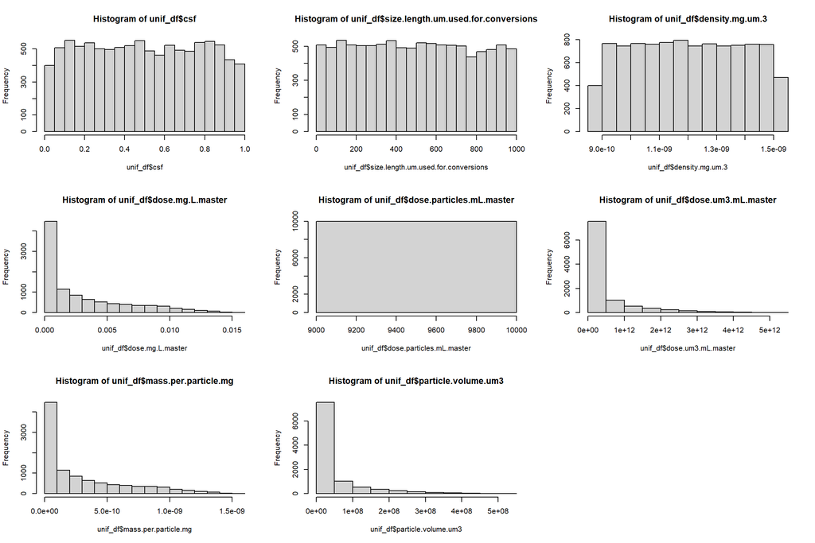

```r
#create a 2 x 3 plotting matrix
par(mfrow = c(3,3))
#plot
hist(unif_df$csf)
hist(unif_df$size.length.um.used.for.conversions)
hist(unif_df$density.mg.um.3)
hist(unif_df$dose.mg.L.master)
hist(unif_df$dose.particles.mL.master)
hist(unif_df$dose.um3.mL.master)
hist(unif_df$mass.per.particle.mg)
hist(unif_df$particle.volume.um3)
#ggplot(unif_df, aes(x = size.category, y =..count..)) + geom_histogram(stat = "count")
```

##### 3.2.1.1.2 Predict toxicities on uniform distribution of particles

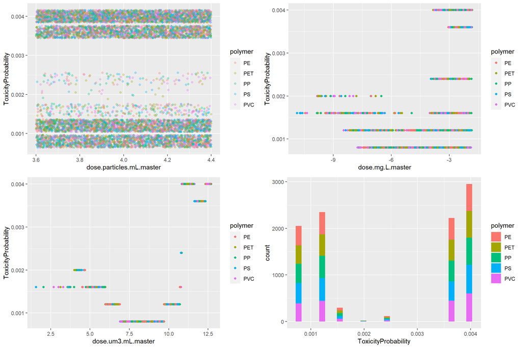

```r
#log transform numeric variables first
unif_df <- unif_df %>%  mutate_if(~is.numeric(.) && (.) > 0, log10) #model has everything log-transformed

#predict tox
unif_pred <- predict(final_model, newdata = unif_df, type = "prob") %>%  rename("ToxicityProbability" = `1`)
uniform_pred <- cbind(unif_pred, unif_df)

#summary(glm(ToxicityProbability ~ Size * Shape * polymer * um3, data = df_640p_p_f))
p1 <- uniform_pred %>% ggplot(aes(x = dose.particles.mL.master, y = ToxicityProbability, color = polymer)) + geom_jitter(alpha = 0.3)

p2 <- uniform_pred %>% ggplot(aes(x = dose.mg.L.master, y = ToxicityProbability, color = polymer)) + geom_point()

p3 <- uniform_pred %>% ggplot(aes(x = dose.um3.mL.master, y = ToxicityProbability, color = polymer)) + geom_point()

p4 <- uniform_pred %>% ggplot(aes(x = ToxicityProbability, fill = polymer)) + geom_histogram()

p5 <- uniform_pred %>%  ggplot(aes(x = size.length.um.used.for.conversions, y = ToxicityProbability, color = csf)) + geom_point()

p6 <- uniform_pred %>%  ggplot(aes(x = csf, y = ToxicityProbability, color = size.length.um.used.for.conversions)) + geom_point()

p7 <- uniform_pred %>%  ggplot(aes(x = particle.volume.um3, y = ToxicityProbability, color =
                                     size.length.um.used.for.conversions)) + geom_point()

p8 <- uniform_pred %>%  ggplot(aes(x = mass.per.particle.mg, y = ToxicityProbability, color =
                                     size.length.um.used.for.conversions)) + geom_point()

p9 <- uniform_pred %>%  ggplot(aes(x = density.mg.um.3, y = ToxicityProbability, color =
                                     size.length.um.used.for.conversions)) + geom_point()

grid.arrange(p1, p2, p3, p4, ncol = 2)
```

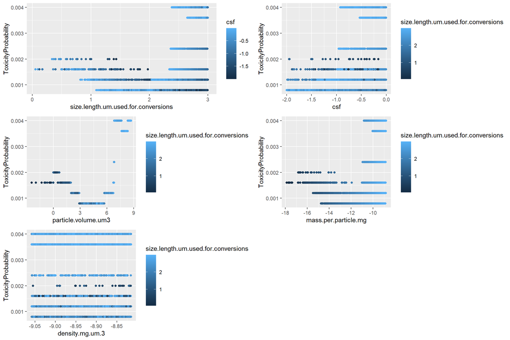

```r
grid.arrange(p5, p6, p7, p8, p9, ncol = 2)
```

```r
summary(lm(ToxicityProbability ~ size.length.um.used.for.conversions * csf * particle.volume.um3, data = uniform_pred))
```

```
##
## Call:
## lm(formula = ToxicityProbability ~ size.length.um.used.for.conversions *
##     csf * particle.volume.um3, data = uniform_pred)
##
## Residuals:
##        Min         1Q     Median         3Q        Max
## -0.0059751 -0.0005414 -0.0001741  0.0006098  0.0015454
##
## Coefficients: (1 not defined because of singularities)
##                                                               Estimate
## (Intercept)                                                  2.003e-03
## size.length.um.used.for.conversions                         -2.611e-03
## csf                                                         -3.458e-03
## particle.volume.um3                                                 NA
## size.length.um.used.for.conversions:csf                      9.092e-04
## size.length.um.used.for.conversions:particle.volume.um3      4.103e-04
## csf:particle.volume.um3                                      6.168e-04
## size.length.um.used.for.conversions:csf:particle.volume.um3 -1.708e-04
##                                                             Std. Error t value
## (Intercept)                                                  1.558e-04  12.853
## size.length.um.used.for.conversions                          1.460e-04 -17.882
## csf                                                          1.750e-04 -19.763
## particle.volume.um3                                                 NA      NA
## size.length.um.used.for.conversions:csf                      9.832e-05   9.248
## size.length.um.used.for.conversions:particle.volume.um3      1.168e-05  35.119
## csf:particle.volume.um3                                      5.455e-05  11.307
## size.length.um.used.for.conversions:csf:particle.volume.um3  1.990e-05  -8.582
##                                                             Pr(>|t|)
## (Intercept)                                                   <2e-16 ***
## size.length.um.used.for.conversions                           <2e-16 ***
## csf                                                           <2e-16 ***
## particle.volume.um3                                               NA
## size.length.um.used.for.conversions:csf                       <2e-16 ***
## size.length.um.used.for.conversions:particle.volume.um3       <2e-16 ***
## csf:particle.volume.um3                                       <2e-16 ***
## size.length.um.used.for.conversions:csf:particle.volume.um3   <2e-16 ***
## ---
## Signif. codes:  0 '***' 0.001 '**' 0.01 '*' 0.05 '.' 0.1 ' ' 1
##
## Residual standard error: 0.0007189 on 9993 degrees of freedom
## Multiple R-squared:  0.7345, Adjusted R-squared:  0.7343
## F-statistic:  4608 on 6 and 9993 DF,  p-value: < 2.2e-16
```

HIGHLIGHT AREA UNDER THE CURVE If we go down to lower number, we would not adequately mimic distribution. Stick to creating 1E5 particles, then change volume. Could capture variability for small bumbers by simulating small number of particles

How to calculate uncertainties? Replace effect parameters by median +- SD, then predict tox for each distribution, plot, then if it is minor, FORGET about it! REsiduals in Merel’s models were not randomly distributed - so imperfect models.

What sizes should be used? 1-5,000 um.

Wait for Merel to update interactions between shape/size/density/count.

What about max size ingest? Tox studies typically do not exposure animals to particles bigger than their mouth size opening, so model may not understand that relationship. Could impose bioavailable fraction AFTER model. JUST do predictions for species that have bioavailable fraction data. Could estimate mouth size from prey to predator fraction. JAMS et al has mouth-size opening parameters.

Non-linear regression to get dose-response.

Mattson, Hasselof, Frontiers in Science - measures size distribution.

# 4 Dose-response curves

# 5 SSD

# 6 Sensitivity Analysis

it would be great to use the full approach to find out which model parameters and MP subclasses the HC5 is most sensitive to.And also if that HC5 is sensitive to which of Merel’s compartment-specific MP parameterisations is used.

# 7 Shiny App Tabs

1. ML predictor
2. Chemical data Bioaccumulation model, partitioning with chemicals/particles. Would add toxicity from chemicals to toxicity from particles! Use same model from Worm paper. Would show how it would compare with toxicities from particles. We have criticial body burden concept (lipids)